# Year of Birth

# 1 Description of DataSchema variable

The description of harmonised variable is the following:

- Short name: `ybirth`
- Variable label: `Year of birth`
- Variable description: `Year of birth`
- Domain: `Socio-demographic and economic characteristics`
- Value type: `Continuous`
- Category missings:

| **Code** | **Category Label** |
| --- | --- |
| 991 | CAPI/interviewer error |
| 992 | Impute |
| 993 | Disable to measure |
| 994 | Not attempt/not done |
| 995 | Does not answer |
| 996 | Not applicable |
| 997 | Refuse |
| 998 | Do not know |
| 999 | Missing |

# 2 Data process

## 2.1 England

**R script:**

```r
# We generate a tbl with all the id (join of all the tables by id)

ELSA_ds_w1 <- tibble(id = ELSA_w1_ybirth$id, yb_w1 = ELSA_w1_ybirth$indobyr)
ELSA_ds_w2 <- tibble(id = ELSA_w2_ybirth$id, yb_w2 = ELSA_w2_ybirth$indobyr)
ELSA_ds_w3 <- tibble(id = ELSA_w3_ybirth$id, yb_w3 = ELSA_w3_ybirth$indobyr)
ELSA_ds_w4 <- tibble(id = ELSA_w4_ybirth$id, yb_w4 = ELSA_w4_ybirth$indobyr)
ELSA_ds_w5 <- tibble(id = ELSA_w5_ybirth$id, yb_w5 = ELSA_w5_ybirth$indobyr)
ELSA_ds_w6 <- tibble(id = ELSA_w6_ybirth$id, yb_w6 = ELSA_w6_ybirth$Indobyr)
ELSA_ds_w7 <- tibble(id = ELSA_w7_ybirth$id, yb_w7 = ELSA_w7_ybirth$Indobyr)
ELSA_ds_join2 <- full_join(ELSA_ds_w1, ELSA_ds_w2, by = "id")
ELSA_ds_join3 <- full_join(ELSA_ds_join2, ELSA_ds_w3, by = "id")
ELSA_ds_join4 <- full_join(ELSA_ds_join3, ELSA_ds_w4, by = "id")
ELSA_ds_join5 <- full_join(ELSA_ds_join4, ELSA_ds_w5, by = "id")
ELSA_ds_join6 <- full_join(ELSA_ds_join5, ELSA_ds_w6, by = "id")
ELSA_ds_join7 <- full_join(ELSA_ds_join6, ELSA_ds_w7, by = "id")


# kable(ELSA_ds_join7,align = 'c')

len_ELSA <- length(ELSA_ds_join7$id)


# We save in a list all the id with the variances corresponding to the
# answered years.

nnvar <- function(x) {
    return(var(as.numeric(ELSA_ds_join7[x, c("yb_w1", "yb_w2", "yb_w3", "yb_w4",
        "yb_w5", "yb_w6", "yb_w7")]), na.rm = T))
}
ntvar <- lapply(1:len_ELSA, nnvar)




# Function computing the mode for a certain data, adapted to avoid missings.
# It returns a length 0 object if all the answers are -7 or other missings.
# When there are two years with the same maximum frequence, they are
# consecutive (we show this below), so, for the sake of simplicity we assume
# the right data is the first year.

statmod <- function(x) {
    z <- table(as.numeric(x))
    z <- z[names(z) != -7 & names(z) != -8 & names(z) != -9 & names(z) != -1]
    z <- names(z)[z == max(z, na.rm = T)]
    z <- z[1]
    return(as.numeric(z))
}

# Function returning the most frequent year (assumed to be the right data)
# for each individual. If there is a unique answer or the variance is 0, the
# year or missing is determined. Otherwise, it uses the previous function.
# In the case an individual has only missings as data and at least two
# numeric, -7 is returned. Later, we will see that it is the only real case
# by showing a table with all the numeric missings but -7.

retyear <- function(x) {
    partv <- as.numeric(ELSA_ds_join7[x, 2:8])
    partv <- partv[!is.na(partv)]
    if (length(partv) == 1 | as.numeric(ntvar[[x]]) == 0) {
        return(partv[1])
    } else {
        if (length(statmod(ELSA_ds_join7[x, 2:8])) != 0) {
            return(statmod(ELSA_ds_join7[x, 2:8]))
        } else {
            return(-7)
        }
    }
}

# One hopes that the data of an individual in each wave it appears is
# numeric. Indeed, this is what we check at the beginning of each
# validation. As a consequence, there is no individual for which all the
# answers are non-numeric (!=-7,-8,-9,-1) missings.


# A table is generated from the lists of id's and assumed to be right years
# respectively, and it is joined by id with the table of all the
# individuals.

rightyear <- lapply(1:len_ELSA, function(x) retyear(x))  # lista
rightyear <- as.integer(unlist(rightyear))
righttib <- tibble(id = ELSA_ds_join7$id, ybirth0 = rightyear)
ELSA_ds_global <- full_join(ELSA_ds_join7, righttib, by = "id")


# Since respondents aged 90 or over are coded as -7, we recode 'ybirth0'
# taking into account the year when the wave of the first data of an
# individual was made. Actually, as all but the last -7 missings are
# interviewed in the wave 1, their years of birth are recoded as 1912, while
# the year of birth of the other, who only was interviewed in the wave 7, is
# recoded as 1924.

mis7list <- ELSA_ds_global$id[ELSA_ds_global$ybirth0 == -7]

for (ind in mis7list) {
    pind <- match(-7, as.numeric(ELSA_ds_global[ELSA_ds_global$id == ind, 2:8]))
    ELSA_ds_global[ELSA_ds_global$id == ind, 9] <- 1910 + 2 * pind
}
```

ybirth0

| Sample size | Missing values |
| --- | --- |
| 18489 | 1 |

Summary

| Min. | 1st Qu. | Median | Mean | 3rd Qu. | Max. |
| --- | --- | --- | --- | --- | --- |
| 1908 | 1934 | 1944 | 1943 | 1952 | 1987 |

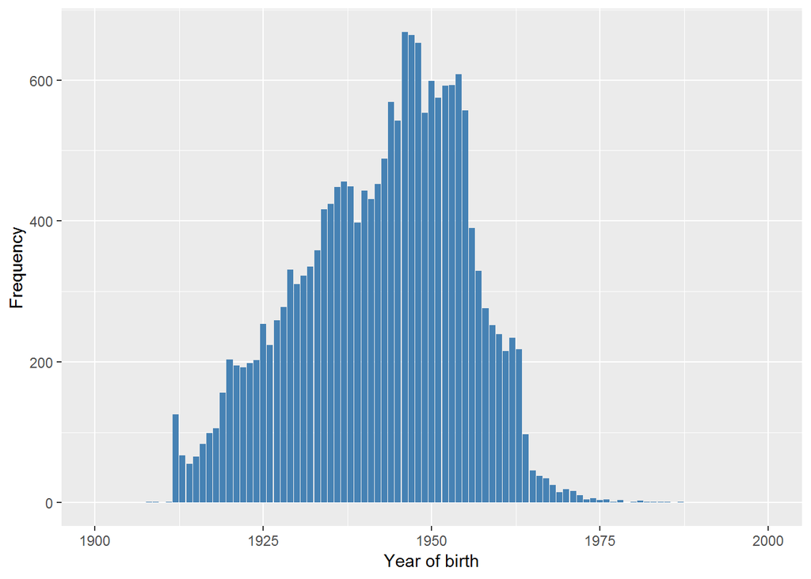

all the numeric missings but -7 and the assumed right year for each individual

| id | yb_w1 | yb_w2 | yb_w3 | yb_w4 | yb_w5 | yb_w6 | yb_w7 | ybirth0 |
| --- | --- | --- | --- | --- | --- | --- | --- | --- |
| 103806 | 1940 | 1940 | 1940 | 1940 | -1 | NA | NA | 1940 |
| 106475 | 1927 | 1927 | 1927 | 1927 | -1 | 1927 | 1927 | 1927 |
| 106899 | 1948 | 1948 | 1948 | 1948 | -1 | 1948 | 1948 | 1948 |
| 112814 | 1950 | 1950 | 1950 | 1950 | -1 | 1950 | 1950 | 1950 |
| 118478 | 1953 | 1953 | 1953 | 1953 | -1 | 1953 | 1953 | 1953 |
| 120150 | 1941 | 1941 | 1941 | 1941 | -1 | NA | NA | 1941 |
| 100016 | NA | NA | -8 | 1952 | NA | NA | NA | 1952 |
| 121375 | NA | NA | -8 | NA | NA | NA | NA | -8 |
| 160286 | NA | NA | NA | 1941 | -1 | 1941 | 1941 | 1941 |

individuals giving as answers two years with the same frequence, and the assumed year

| id | yb_w1 | yb_w2 | yb_w3 | yb_w4 | yb_w5 | yb_w6 | yb_w7 | ybirth0 |
| --- | --- | --- | --- | --- | --- | --- | --- | --- |
| 100072 | 1946 | 1947 | NA | NA | NA | NA | NA | 1946 |
| 104973 | 1944 | NA | 1943 | NA | NA | NA | NA | 1943 |
| 106070 | 1926 | 1926 | 1925 | 1925 | NA | NA | NA | 1925 |
| 164906 | NA | NA | NA | NA | 1960 | 1961 | NA | 1960 |

### 2.1.1 Wave 1

#### 2.1.1.1 Study-specific variable description

| **Name** | `indobyr` |
| --- | --- |
| **Label** | `Year of birth combined HH grid and individual demographics collapsed at 90 plus` |
| **Table name** | `wave_1_core_data_v3` |
| **Missings** | `-7 = DOB on or before 29/02/1912 collapsed to avoid disclosure` |
| **Description** |  |

indobyr

| Sample size | Missing values |
| --- | --- |
| 12099 | 95 |

Summary

| Min. | 1st Qu. | Median | Mean | 3rd Qu. | Max. |
| --- | --- | --- | --- | --- | --- |
| 1912 | 1930 | 1939 | 1938 | 1946 | 1981 |

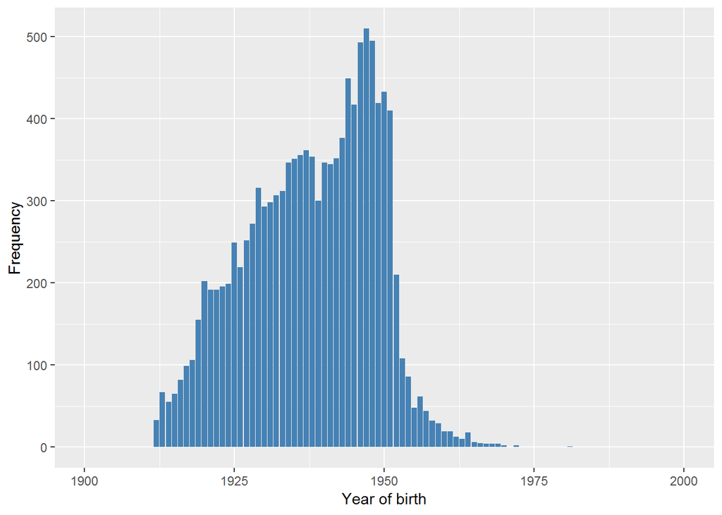

#### 2.1.1.2 Harmonisation algorithm

The harmonized variable is the same than the study-specific variable, but the missing values have to be recoded as follows:

- `keep "DOB on or before 29/02/1912 collapsed to avoid disclosure" as born into 1912. This is done by means of joining with the global table, where data was suitably transformed above`
- `NA into 999`

**R script:**

```r
# We save all the known answers for the individuals of the wave 1 from the
# global table built at the beginning.
ELSA_ds_w1 <- left_join(ELSA_ds_w1, ELSA_ds_global[, c(1, 9)], by = "id")[,
    c(1, 3)]
names(ELSA_ds_w1)[2] <- "ybirth"


ELSA_ds_w1$ybirth <- car::recode(ELSA_ds_w1$ybirth, "NA='999'")
ELSA_ds_w1$ybirth <- labelled(ELSA_ds_w1$ybirth, labels = c(Missing = 999, `Do not know` = 998,
    Refuse = 997, `Not attempt not done` = 994, `Does not answer` = 995, `Not applicable` = 996,
    `Disable to measure` = 993, Impute = 992, `CAPI interviewer error` = 991))
```

#### 2.1.1.3 Statistics of the new harmonised variable

| Sample size | Missing values |
| --- | --- |
| 12099 | 0 |

Values

|  | No-missings | 991 | 992 | 993 | 994 | 995 | 996 | 997 | 998 | 999 | NA |
| --- | --- | --- | --- | --- | --- | --- | --- | --- | --- | --- | --- |
| Frequency | 12099 | 0 | 0 | 0 | 0 | 0 | 0 | 0 | 0 | 0 | 0 |
| Percentage | 100 | 0 | 0 | 0 | 0 | 0 | 0 | 0 | 0 | 0 | 0 |

Summary

| Min. | 1st Qu. | Median | Mean | 3rd Qu. | Max. |
| --- | --- | --- | --- | --- | --- |
| 1908 | 1929 | 1939 | 1938 | 1946 | 1981 |

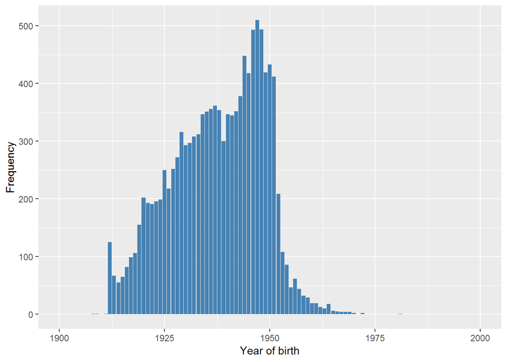

#### 2.1.1.4 Validation

The differences which are not due to corrected missings are 11

years non validated

| id | yb_w1 | yb_w2 | yb_w3 | yb_w4 | yb_w5 | yb_w6 | yb_w7 | ybirth0 |
| --- | --- | --- | --- | --- | --- | --- | --- | --- |
| 100098 | 1931 | 1932 | 1932 | 1932 | 1932 | 1932 | 1932 | 1932 |
| 104487 | 1922 | 1922 | 1921 | 1921 | 1921 | -7 | -7 | 1921 |
| 104973 | 1944 | NA | 1943 | NA | NA | NA | NA | 1943 |
| 105195 | 1952 | 1951 | 1952 | 1951 | 1951 | 1951 | 1951 | 1951 |
| 106070 | 1926 | 1926 | 1925 | 1925 | NA | NA | NA | 1925 |
| 106246 | 1941 | 1941 | NA | 1951 | NA | 1951 | 1951 | 1951 |
| 106748 | 1948 | NA | 1945 | 1945 | 1945 | NA | NA | 1945 |
| 106893 | 1942 | 1941 | 1942 | 1941 | 1941 | 1941 | 1941 | 1941 |
| 117682 | 1944 | 1942 | 1942 | 1942 | 1942 | 1942 | 1942 | 1942 |
| 118379 | 1948 | 1944 | 1944 | NA | NA | NA | NA | 1944 |
| 120623 | 1955 | 1948 | 1948 | NA | 1948 | 1948 | 1948 | 1948 |

We note that the non validation of certain years is due to the fact that they are not the most frequent along the different waves answers, so they were corrected.

### 2.1.2 Wave 2

#### 2.1.2.1 Study-specific variable description

| **Name** | `indobyr` |
| --- | --- |
| **Label** | `Year of birth combined HH grid and individual demographics collapsed at 90 plus` |
| **Table name** | `wave_2_core_data_v4` |
| **Missings** | `-9 = Refusal; -8 = Don't know; -7 = DOB on or before 29/02/1914 collapsed to avoid disclosure; -1 = Not applicable` |
| **Description** |  |

indobyr

| Sample size | Missing values |
| --- | --- |
| 9432 | 109 |

Summary

| Min. | 1st Qu. | Median | Mean | 3rd Qu. | Max. |
| --- | --- | --- | --- | --- | --- |
| 1914 | 1931 | 1940 | 1939 | 1947 | 1987 |

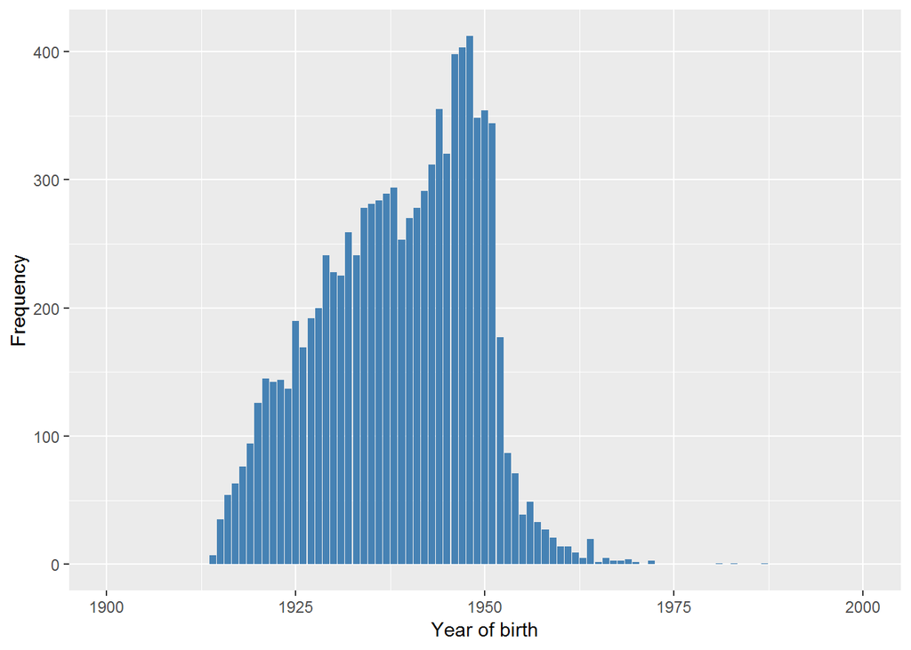

#### 2.1.2.2 Harmonisation algorithm

The harmonized variable is the same than the study-specific variable, but the missing values have to be recoded as follows:

- `recode -9 "Refusal" into 997`
- `recode -8 "Don't know" into 998`
- `keep "DOB on or before 29/02/1914 collapsed to avoid disclosure" as born into 1914. This is done by means of joining with the global table, where data was suitably transformed above`
- `recode -1 "Not applicable" into 996`
- `NA into 999`

**R script:**

```r
# We save all the known answers for the individuals of the wave 2 from the
# global table built at the beginning.
ELSA_ds_w2 <- left_join(ELSA_ds_w2, ELSA_ds_global[, c(1, 9)], by = "id")[,
    c(1, 3)]
names(ELSA_ds_w2)[2] <- "ybirth"



ELSA_ds_w2$ybirth <- car::recode(ELSA_ds_w2$ybirth, "-9=997; -8=998; -1=996; NA=999")
ELSA_ds_w2$ybirth <- labelled(ELSA_ds_w2$ybirth, labels = c(Missing = 999, `Do not know` = 998,
    Refuse = 997, `Not attempt not done` = 994, `Does not answer` = 995, `Not applicable` = 996,
    `Disable to measure` = 993, Impute = 992, `CAPI interviewer error` = 991))
```

#### 2.1.2.3 Statistics of the new harmonised variable

| Sample size | Missing values |
| --- | --- |
| 9432 | 0 |

Values

|  | No-missings | 991 | 992 | 993 | 994 | 995 | 996 | 997 | 998 | 999 | NA |
| --- | --- | --- | --- | --- | --- | --- | --- | --- | --- | --- | --- |
| Frequency | 9432 | 0 | 0 | 0 | 0 | 0 | 0 | 0 | 0 | 0 | 0 |
| Percentage | 100 | 0 | 0 | 0 | 0 | 0 | 0 | 0 | 0 | 0 | 0 |

Summary

| Min. | 1st Qu. | Median | Mean | 3rd Qu. | Max. |
| --- | --- | --- | --- | --- | --- |
| 1908 | 1931 | 1939 | 1938 | 1947 | 1987 |

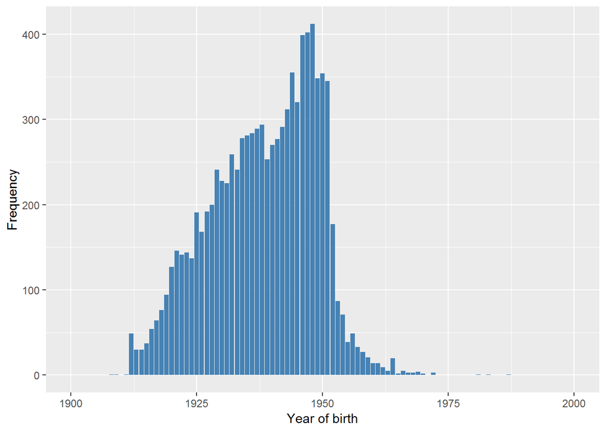

#### 2.1.2.4 Validation

The differences which are not due to corrected missings are 4

years non validated

| id | yb_w1 | yb_w2 | yb_w3 | yb_w4 | yb_w5 | yb_w6 | yb_w7 | ybirth0 |
| --- | --- | --- | --- | --- | --- | --- | --- | --- |
| 100072 | 1946 | 1947 | NA | NA | NA | NA | NA | 1946 |
| 104487 | 1922 | 1922 | 1921 | 1921 | 1921 | -7 | -7 | 1921 |
| 106070 | 1926 | 1926 | 1925 | 1925 | NA | NA | NA | 1925 |
| 106246 | 1941 | 1941 | NA | 1951 | NA | 1951 | 1951 | 1951 |

We note that the non validation of certain years is due to the fact that they are not the most frequent along the different waves answers, so they were corrected.

### 2.1.3 Wave 3

#### 2.1.3.1 Study-specific variable description

| **Name** | `indobyr` |
| --- | --- |
| **Label** | `Definitive year of birth collapsed at 90 plus. Priority: Didbn, Dhdob` |
| **Table name** | `wave_3_elsa_data_v4` |
| **Missings** | `-9 = Refusal; -8 = Don't know; -7 = DOB collapsed as on or before 29/02/1916; -1 = Not applicable` |
| **Description** |  |

indobyr

| Sample size | Missing values |
| --- | --- |
| 9771 | 118 |

Summary

| Min. | 1st Qu. | Median | Mean | 3rd Qu. | Max. |
| --- | --- | --- | --- | --- | --- |
| 1916 | 1934 | 1943 | 1942 | 1950 | 1987 |

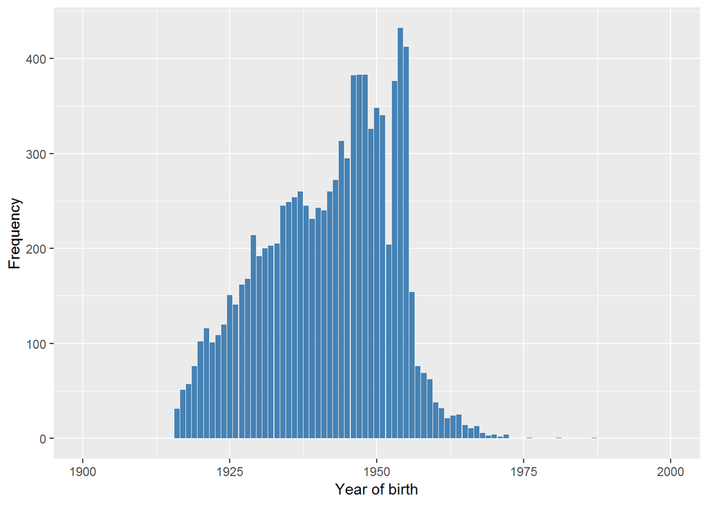

#### 2.1.3.2 Harmonisation algorithm

The harmonized variable is the same than the study-specific variable, but the missing values have to be recoded as follows:

- `recode -9 "Refusal" into 997`
- `recode -8 "Don't know" into 998`
- `keep "DOB collapsed as on or before 29/02/1916" as born into 1916. This is done by means of joining with the global table, where data was suitably transformed above`
- `recode -1 "Not applicable" into 996`
- `NA into 999`

**R script:**

```r
# We save all the known answers for the individuals of the wave 3 from the
# global table built at the beginning.
ELSA_ds_w3 <- left_join(ELSA_ds_w3, ELSA_ds_global[, c(1, 9)], by = "id")[,
    c(1, 3)]
names(ELSA_ds_w3)[2] <- "ybirth"


ELSA_ds_w3$ybirth <- car::recode(ELSA_ds_w3$ybirth, "-9=997; -8=998; -1=996; NA=999")
ELSA_ds_w3$ybirth <- labelled(ELSA_ds_w3$ybirth, labels = c(Missing = 999, `Do not know` = 998,
    Refuse = 997, `Not attempt not done` = 994, `Does not answer` = 995, `Not applicable` = 996,
    `Disable to measure` = 993, Impute = 992, `CAPI interviewer error` = 991))
```

#### 2.1.3.3 Statistics of the new harmonised variable

| Sample size | Missing values |
| --- | --- |
| 9771 | 1 |

Values

|  | No-missings | 991 | 992 | 993 | 994 | 995 | 996 | 997 | 998 | 999 | NA |
| --- | --- | --- | --- | --- | --- | --- | --- | --- | --- | --- | --- |
| Frequency | 9770.00 | 0 | 0 | 0 | 0 | 0 | 0 | 0 | 1.00 | 0 | 0 |
| Percentage | 99.99 | 0 | 0 | 0 | 0 | 0 | 0 | 0 | 0.01 | 0 | 0 |

Summary

| Min. | 1st Qu. | Median | Mean | 3rd Qu. | Max. |
| --- | --- | --- | --- | --- | --- |
| 1908 | 1933 | 1943 | 1941 | 1950 | 1987 |

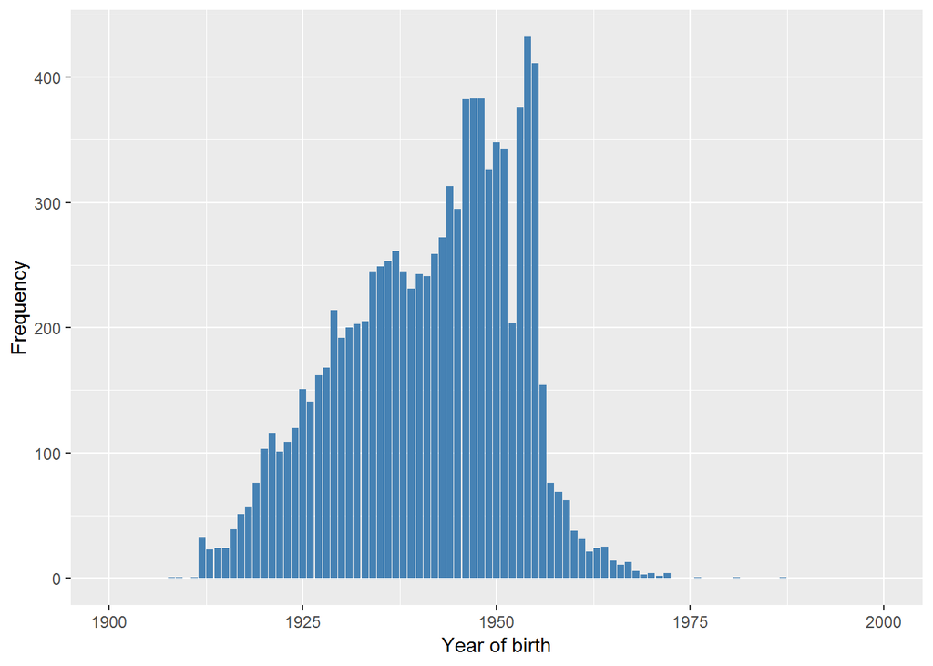

#### 2.1.3.4 Validation

The differences which are not due to corrected missings are 6

years non validated

| id | yb_w1 | yb_w2 | yb_w3 | yb_w4 | yb_w5 | yb_w6 | yb_w7 | ybirth0 |
| --- | --- | --- | --- | --- | --- | --- | --- | --- |
| 105195 | 1952 | 1951 | 1952 | 1951 | 1951 | 1951 | 1951 | 1951 |
| 106893 | 1942 | 1941 | 1942 | 1941 | 1941 | 1941 | 1941 | 1941 |
| 112617 | 1937 | 1937 | 1936 | NA | NA | NA | NA | 1937 |
| 103161 | NA | NA | 1952 | 1952 | 1951 | 1951 | 1951 | 1951 |
| 121374 | NA | NA | 1961 | 1951 | 1951 | 1951 | NA | 1951 |
| 151415 | NA | NA | 1955 | 1952 | 1952 | 1952 | 1952 | 1952 |

We note that the non validation of certain years is due to the fact that they are not the most frequent along the different waves answers, so they were corrected.

### 2.1.4 Wave 4

#### 2.1.4.1 Study-specific variable description

| **Name** | `indobyr` |
| --- | --- |
| **Label** | `Definitive year of birth collapsed at 90 plus. Priority: Didbn, Dhdob` |
| **Table name** | `wave_4_elsa_data_v3` |
| **Missings** | `-7 = DOB collapsed if aged 90 or over at interview` |
| **Description** |  |

indobyr

| Sample size | Missing values |
| --- | --- |
| 11050 | 137 |

Summary

| Min. | 1st Qu. | Median | Mean | 3rd Qu. | Max. |
| --- | --- | --- | --- | --- | --- |
| 1918 | 1936 | 1944 | 1943 | 1951 | 1984 |

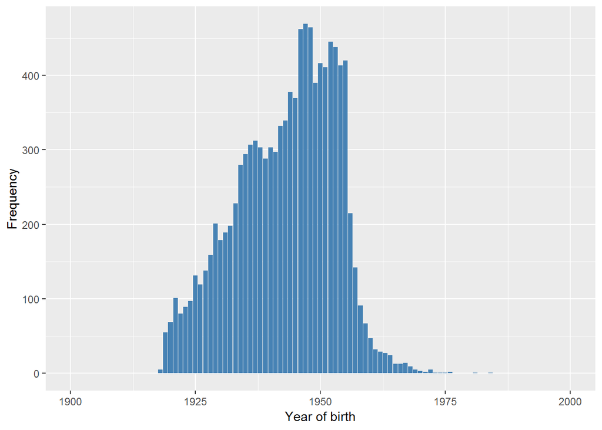

#### 2.1.4.2 Harmonisation algorithm

The harmonized variable is the same than the study-specific variable, but the missing values have to be recoded as follows:

- `keep "DOB collapsed if aged 90 or over at interview" as born into 1918. This is done by means of joining with the global table, where data was suitably transformed above`
- `NA into 999`

**R script:**

```r
# We save all the known answers for the individuals of the wave 4 from the
# global table built at the beginning.
ELSA_ds_w4 <- left_join(ELSA_ds_w4, ELSA_ds_global[, c(1, 9)], by = "id")[,
    c(1, 3)]
names(ELSA_ds_w4)[2] <- "ybirth"

ELSA_ds_w4$ybirth <- car::recode(ELSA_ds_w4$ybirth, "NA=999")
ELSA_ds_w4$ybirth <- labelled(ELSA_ds_w4$ybirth, labels = c(Missing = 999, `Do not know` = 998,
    Refuse = 997, `Not attempt not done` = 994, `Does not answer` = 995, `Not applicable` = 996,
    `Disable to measure` = 993, Impute = 992, `CAPI interviewer error` = 991))
```

#### 2.1.4.3 Statistics of the new harmonised variable

| Sample size | Missing values |
| --- | --- |
| 11050 | 0 |

Values

|  | No-missings | 991 | 992 | 993 | 994 | 995 | 996 | 997 | 998 | 999 | NA |
| --- | --- | --- | --- | --- | --- | --- | --- | --- | --- | --- | --- |
| Frequency | 11050 | 0 | 0 | 0 | 0 | 0 | 0 | 0 | 0 | 0 | 0 |
| Percentage | 100 | 0 | 0 | 0 | 0 | 0 | 0 | 0 | 0 | 0 | 0 |

Summary

| Min. | 1st Qu. | Median | Mean | 3rd Qu. | Max. |
| --- | --- | --- | --- | --- | --- |
| 1908 | 1936 | 1944 | 1943 | 1951 | 1984 |

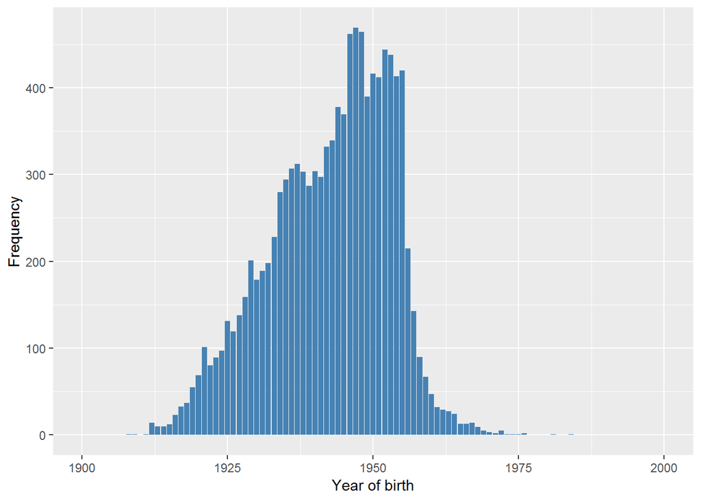

#### 2.1.4.4 Validation

The differences which are not due to corrected missings are 3

years non validated

| id | yb_w1 | yb_w2 | yb_w3 | yb_w4 | yb_w5 | yb_w6 | yb_w7 | ybirth0 |
| --- | --- | --- | --- | --- | --- | --- | --- | --- |
| 103161 | NA | NA | 1952 | 1952 | 1951 | 1951 | 1951 | 1951 |
| 121414 | NA | NA | NA | 1958 | 1957 | 1957 | 1957 | 1957 |
| 164002 | NA | NA | NA | 1939 | 1940 | 1940 | 1940 | 1940 |

We note that the non validation of certain years is due to the fact that they are not the most frequent along the different waves answers, so they were corrected.

### 2.1.5 Wave 5

#### 2.1.5.1 Study-specific variable description

| **Name** | `indobyr` |
| --- | --- |
| **Label** | `Definitive year of birth collapsed at 90 plus. Priority: Didbn, Dhdob` |
| **Table name** | `wave_5_elsa_data_v4` |
| **Missings** | `-7 = DOB on or before 29/02/1920 collapsed to avoid disclosure; -1 = Not applicable` |
| **Description** |  |

indobyr

| Sample size | Missing values |
| --- | --- |
| 10274 | 134 |

Summary

| Min. | 1st Qu. | Median | Mean | 3rd Qu. | Max. |
| --- | --- | --- | --- | --- | --- |
| 1908 | 1937 | 1945 | 1943 | 1951 | 1984 |

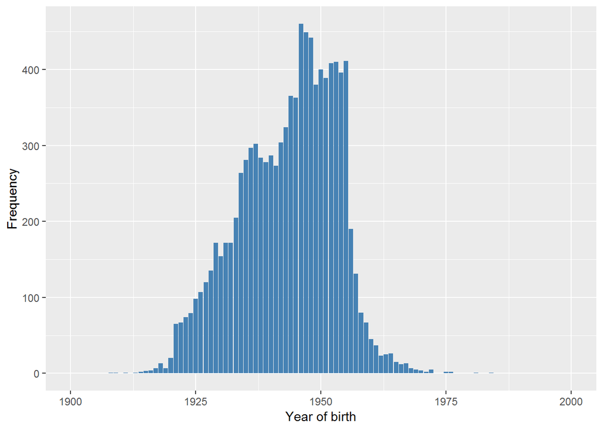

#### 2.1.5.2 Harmonisation algorithm

The harmonized variable is the same than the study-specific variable, but the missing values have to be recoded as follows:

- `keep "DOB on or before 29/02/1920 collapsed to avoid disclosure" as born into 1920. This is done by means of joining with the global table, where data was suitably transformed above`
- `recode -1 "Not applicable" into 996`
- `NA into 999`

**R script:**

```r
# We save all the known answers for the individuals of the wave 5 from the
# global table built at the beginning.
ELSA_ds_w5 <- left_join(ELSA_ds_w5, ELSA_ds_global[, c(1, 9)], by = "id")[,
    c(1, 3)]
names(ELSA_ds_w5)[2] <- "ybirth"

ELSA_ds_w5$ybirth <- car::recode(ELSA_ds_w5$ybirth, "-1=996; NA=999")
ELSA_ds_w5$ybirth <- labelled(ELSA_ds_w5$ybirth, labels = c(Missing = 999, `Do not know` = 998,
    Refuse = 997, `Not attempt not done` = 994, `Does not answer` = 995, `Not applicable` = 996,
    `Disable to measure` = 993, Impute = 992, `CAPI interviewer error` = 991))
```

#### 2.1.5.3 Statistics of the new harmonised variable

| Sample size | Missing values |
| --- | --- |
| 10274 | 0 |

Values

|  | No-missings | 991 | 992 | 993 | 994 | 995 | 996 | 997 | 998 | 999 | NA |
| --- | --- | --- | --- | --- | --- | --- | --- | --- | --- | --- | --- |
| Frequency | 10274 | 0 | 0 | 0 | 0 | 0 | 0 | 0 | 0 | 0 | 0 |
| Percentage | 100 | 0 | 0 | 0 | 0 | 0 | 0 | 0 | 0 | 0 | 0 |

Summary

| Min. | 1st Qu. | Median | Mean | 3rd Qu. | Max. |
| --- | --- | --- | --- | --- | --- |
| 1908 | 1936 | 1945 | 1943 | 1951 | 1984 |

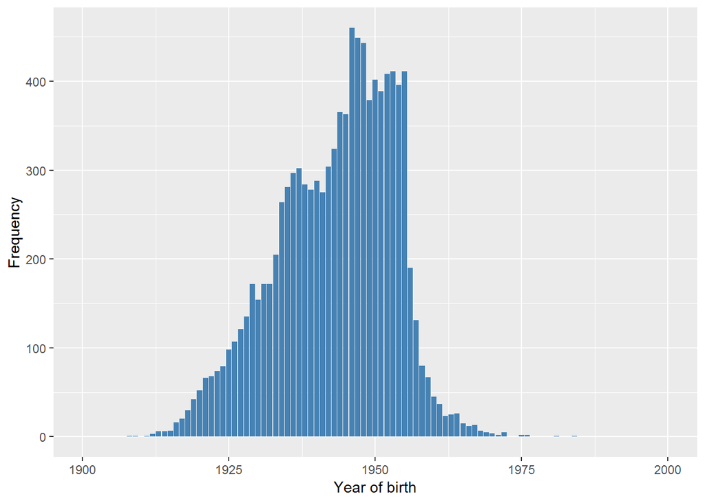

#### 2.1.5.4 Validation

The differences which are not due to corrected missings are 1

years non validated

| id | yb_w1 | yb_w2 | yb_w3 | yb_w4 | yb_w5 | yb_w6 | yb_w7 | ybirth0 |
| --- | --- | --- | --- | --- | --- | --- | --- | --- |
| 164920 | NA | NA | NA | NA | 1949 | 1950 | 1950 | 1950 |

We note that the non validation of certain years is due to the fact that they are not the most frequent along the different waves answers, so they were corrected.

### 2.1.6 Wave 6

#### 2.1.6.1 Study-specific variable description

| **Name** | `Indobyr` |
| --- | --- |
| **Label** | `Definitive year of birth collapsed at 90 plus` |
| **Table name** | `wave_6_elsa_data_v2` |
| **Missings** | `-7 = DOB collapsed if aged 90 or over at interview` |
| **Description** |  |

Indobyr

| Sample size | Missing values |
| --- | --- |
| 10601 | 207 |

Summary

| Min. | 1st Qu. | Median | Mean | 3rd Qu. | Max. |
| --- | --- | --- | --- | --- | --- |
| 1922 | 1939 | 1947 | 1946 | 1953 | 1984 |

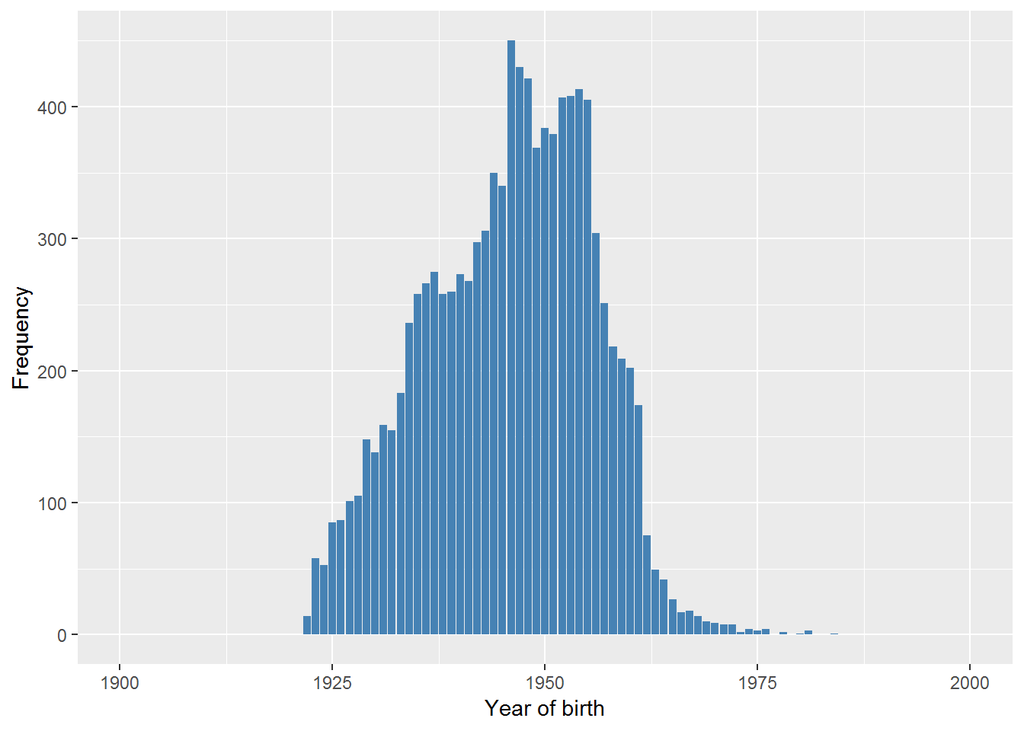

#### 2.1.6.2 Harmonisation algorithm

The harmonized variable is the same than the study-specific variable, but the missing values have to be recoded as follows:

- `keep "DOB collapsed if aged 90 or over at interview" as born into 1922. This is done by means of joining with the global table, where data was suitably transformed above`
- `NA into 999`

**R script:**

```r
# We save all the known answers for the individuals of the wave 6 from the
# global table built at the beginning.
ELSA_ds_w6 <- left_join(ELSA_ds_w6, ELSA_ds_global[, c(1, 9)], by = "id")[,
    c(1, 3)]
names(ELSA_ds_w6)[2] <- "ybirth"

ELSA_ds_w6$ybirth <- car::recode(ELSA_ds_w6$ybirth, "NA=999")
ELSA_ds_w6$ybirth <- labelled(ELSA_ds_w6$ybirth, labels = c(Missing = 999, `Do not know` = 998,
    Refuse = 997, `Not attempt not done` = 994, `Does not answer` = 995, `Not applicable` = 996,
    `Disable to measure` = 993, Impute = 992, `CAPI interviewer error` = 991))
```

#### 2.1.6.3 Statistics of the new harmonised variable

| Sample size | Missing values |
| --- | --- |
| 10601 | 0 |

Values

|  | No-missings | 991 | 992 | 993 | 994 | 995 | 996 | 997 | 998 | 999 | NA |
| --- | --- | --- | --- | --- | --- | --- | --- | --- | --- | --- | --- |
| Frequency | 10601 | 0 | 0 | 0 | 0 | 0 | 0 | 0 | 0 | 0 | 0 |
| Percentage | 100 | 0 | 0 | 0 | 0 | 0 | 0 | 0 | 0 | 0 | 0 |

Summary

| Min. | 1st Qu. | Median | Mean | 3rd Qu. | Max. |
| --- | --- | --- | --- | --- | --- |
| 1911 | 1938 | 1946 | 1945 | 1953 | 1984 |

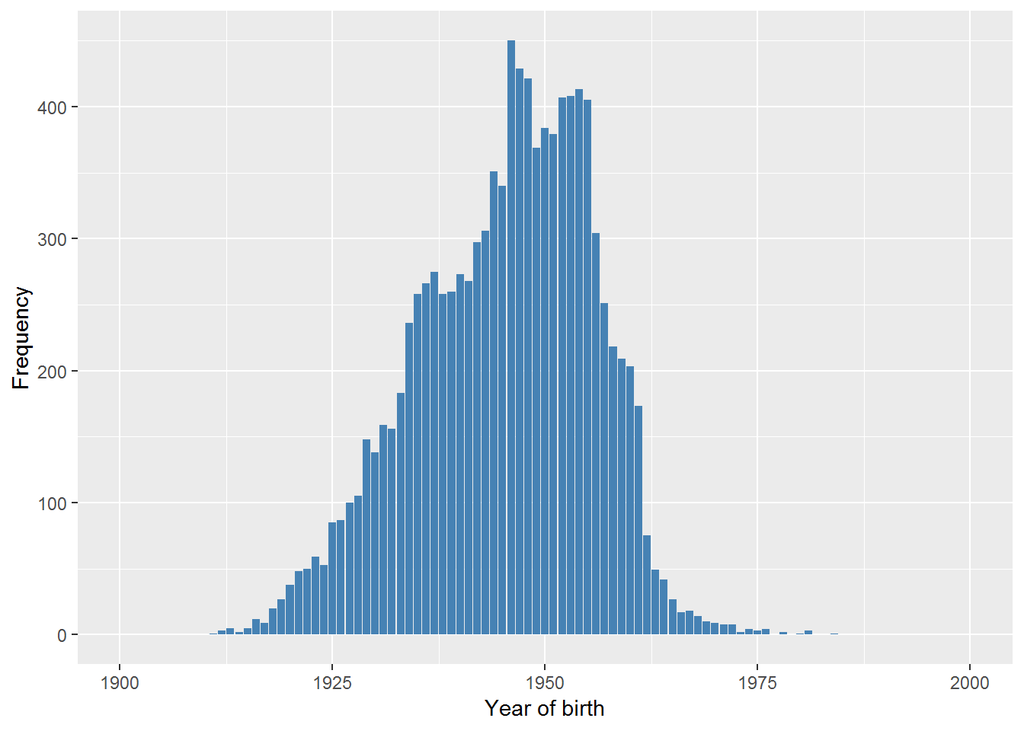

#### 2.1.6.4 Validation

The differences which are not due to corrected missings are 3

years non validated

| id | yb_w1 | yb_w2 | yb_w3 | yb_w4 | yb_w5 | yb_w6 | yb_w7 | ybirth0 |
| --- | --- | --- | --- | --- | --- | --- | --- | --- |
| 116908 | 1932 | 1932 | 1932 | 1932 | 1932 | 1927 | 1927 | 1932 |
| 120955 | 1944 | 1944 | 1944 | 1944 | 1944 | 1947 | 1947 | 1944 |
| 164906 | NA | NA | NA | NA | 1960 | 1961 | NA | 1960 |

We note that the non validation of certain years is due to the fact that they are not the most frequent along the different waves answers, so they were corrected.

### 2.1.7 Wave 7

#### 2.1.7.1 Study-specific variable description

| **Name** | `Indobyr` |
| --- | --- |
| **Label** | `Definitive year of birth collapsed at 90 plus` |
| **Table name** | `wave_7_elsa_data` |
| **Missings** | `-7 = DOB collapsed if aged 90 or over at interview` |
| **Description** |  |

Indobyr

| Sample size | Missing values |
| --- | --- |
| 9666 | 193 |

Summary

| Min. | 1st Qu. | Median | Mean | 3rd Qu. | Max. |
| --- | --- | --- | --- | --- | --- |
| 1924 | 1940 | 1948 | 1947 | 1954 | 1985 |

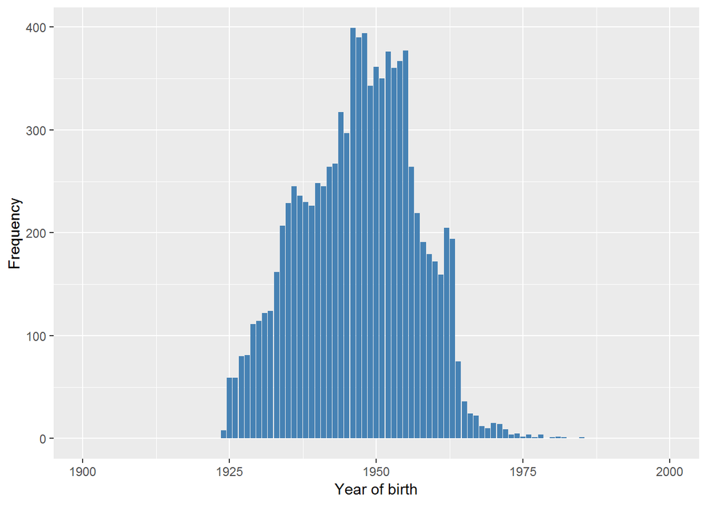

#### 2.1.7.2 Harmonisation algorithm

The harmonized variable is the same than the study-specific variable, but the missing values have to be recoded as follows:

- `keep "DOB collapsed if aged 90 or over at interview" as born into 1924. This is done by means of joining with the global table, where data was suitably transformed above`
- `NA into 999`

**R script:**

```r
# We save all the known answers for the individuals of the wave 7 from the
# global table built at the beginning.
ELSA_ds_w7 <- left_join(ELSA_ds_w7, ELSA_ds_global[, c(1, 9)], by = "id")[,
    c(1, 3)]
names(ELSA_ds_w7)[2] <- "ybirth"

ELSA_ds_w7$ybirth <- car::recode(ELSA_ds_w7$ybirth, "NA=999")
ELSA_ds_w7$ybirth <- labelled(ELSA_ds_w7$ybirth, labels = c(Missing = 999, `Do not know` = 998,
    Refuse = 997, `Not attempt not done` = 994, `Does not answer` = 995, `Not applicable` = 996,
    `Disable to measure` = 993, Impute = 992, `CAPI interviewer error` = 991))
```

#### 2.1.7.3 Statistics of the new harmonised variable

| Sample size | Missing values |
| --- | --- |
| 9666 | 0 |

Values

|  | No-missings | 991 | 992 | 993 | 994 | 995 | 996 | 997 | 998 | 999 | NA |
| --- | --- | --- | --- | --- | --- | --- | --- | --- | --- | --- | --- |
| Frequency | 9666 | 0 | 0 | 0 | 0 | 0 | 0 | 0 | 0 | 0 | 0 |
| Percentage | 100 | 0 | 0 | 0 | 0 | 0 | 0 | 0 | 0 | 0 | 0 |

Summary

| Min. | 1st Qu. | Median | Mean | 3rd Qu. | Max. |
| --- | --- | --- | --- | --- | --- |
| 1911 | 1939 | 1947 | 1946 | 1954 | 1985 |

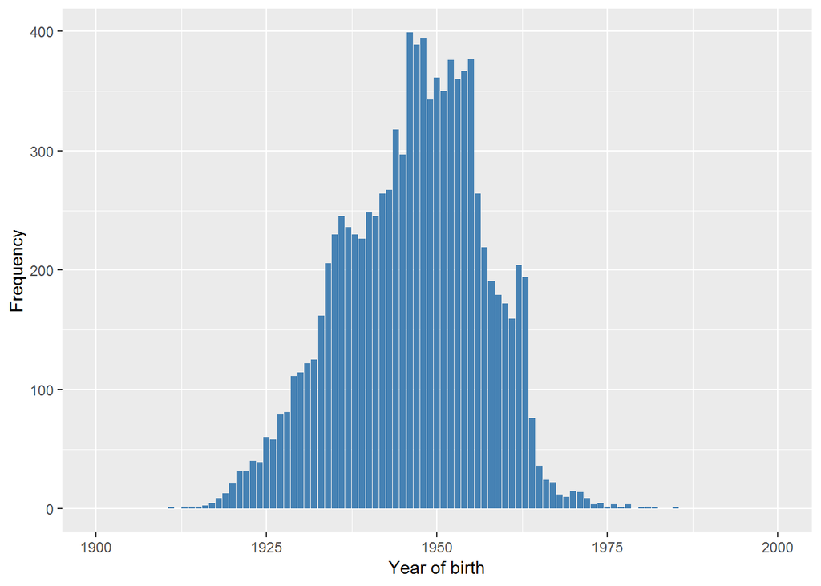

#### 2.1.7.4 Validation

The differences which are not due to corrected missings are 5

years non validated

| id | yb_w1 | yb_w2 | yb_w3 | yb_w4 | yb_w5 | yb_w6 | yb_w7 | ybirth0 |
| --- | --- | --- | --- | --- | --- | --- | --- | --- |
| 104511 | 1924 | 1924 | 1924 | 1924 | 1924 | 1924 | 1926 | 1924 |
| 116908 | 1932 | 1932 | 1932 | 1932 | 1932 | 1927 | 1927 | 1932 |
| 117630 | 1935 | 1935 | 1935 | NA | 1935 | NA | 1934 | 1935 |
| 120955 | 1944 | 1944 | 1944 | 1944 | 1944 | 1947 | 1947 | 1944 |
| 164914 | NA | NA | NA | NA | 1964 | 1964 | 1962 | 1964 |

We note that the non validation of certain years is due to the fact that they are not the most frequent along the different waves answers, so they were corrected.

## 2.2 Summary of descriptive statistics of the harmonised variable accross populations and waves

Year of birth

| ybirth | W1 | W2 | W3 | W4 | W5 | W6 | W7 |
| --- | --- | --- | --- | --- | --- | --- | --- |
| Min. | 1908 | 1908 | 1908 | 1908 | 1908 | 1911 | 1911 |
| 1st Qu. | 1929 | 1931 | 1933 | 1936 | 1936 | 1938 | 1939 |
| Median | 1939 | 1939 | 1943 | 1944 | 1945 | 1946 | 1947 |
| Mean | 1938 | 1938 | 1941 | 1943 | 1943 | 1945 | 1946 |
| 3rd Qu. | 1946 | 1947 | 1950 | 1951 | 1951 | 1953 | 1954 |
| Max. | 1981 | 1987 | 1987 | 1984 | 1984 | 1984 | 1985 |
| No-missings | 12099 | 9432 | 9770 | 11050 | 10274 | 10601 | 9666 |
| 991 | 0 | 0 | 0 | 0 | 0 | 0 | 0 |
| 992 | 0 | 0 | 0 | 0 | 0 | 0 | 0 |
| 993 | 0 | 0 | 0 | 0 | 0 | 0 | 0 |
| 994 | 0 | 0 | 0 | 0 | 0 | 0 | 0 |
| 995 | 0 | 0 | 0 | 0 | 0 | 0 | 0 |
| 996 | 0 | 0 | 0 | 0 | 0 | 0 | 0 |
| 997 | 0 | 0 | 0 | 0 | 0 | 0 | 0 |
| 998 | 0 | 0 | 1 | 0 | 0 | 0 | 0 |
| 999 | 0 | 0 | 0 | 0 | 0 | 0 | 0 |
| NA | 0 | 0 | 0 | 0 | 0 | 0 | 0 |
| sample size | 12099 | 9432 | 9771 | 11050 | 10274 | 10601 | 9666 |

# 3 Quality estimation

Years of birth of respondents aged 90 or over were imputed to 90 years ago of the first wave in which they took part.